# drillerの部屋

2018-12-13 finance

# ポートフォリオのリスクを分析する

[「FinTech Advent Calendar 2018」](https://qiita.com/advent-calendar/2018/fintech)の記事です。  
Pythonのライブラリを使ってポートフォリオのリスクを分析してみます。

## データの準備

手っ取り早くデータを取りたいので、今回はQuandlを使います。  
株価のデータは有料なものがほとんどで世知辛いので、先物のデータを使います。

- 天然ガス(1限月)  
  なんとなく選んだ、特に意味はない
- E-Mini S&P 500(1限月)  
  ベンチマークとして使用

```python
import quandl

# 天然ガス(1限月)
ng_df = quandl.get("CHRIS/CME_NG1", start_date="1998-01-01", )
# E-Mini S&P 500(1限月)
es_df = quandl.get("CHRIS/CME_ES1", start_date="1998-01-01")
```

今後はデイリーのリターンを使うので事前に計算します。

```python
ng_returns = ng_df["Settle"].pct_change()
es_returns = es_df["Settle"].pct_change()
```

## [empyrical](http://quantopian.github.io/empyrical/)

さまざまなリスクメトリクスを算出できます。

### Alpha

ベンチマークをどれだけ超過できるか

$$ \mathrm{SCL} : R_{i,t} - R_{f} = \alpha_i + \beta_i\, ( R_{M,t} - R_{f} ) + \epsilon_{i,t} \frac{}{} $$

```python
import empyrical

empyrical.alpha(ng_returns, es_returns)
```

```
0.1574354286270515
```

### Beta

ベンチマークに対する相関

$$ \beta = \frac {\mathrm{Cov}(r_a,r_b)}{\mathrm{Var}(r_b)}, $$

```python
empyrical.beta(ng_returns, es_returns)
```

```
0.07876259288959367
```

AlphaとBetaは算出時に共通する部分があるため、同時に算出する関数が用意されています。

```python
empyrical.alpha_beta(ng_returns, es_returns)
```

```
array([0.15743543, 0.07876259])
```

### maximum drawdown

最大ドローダウン

```python
empyrical.max_drawdown(ng_returns)
```

```
-0.8934191702432047
```

### annual growth rate of returns

年平均成長率

```python
empyrical.annual_return(ng_returns)
```

```
0.03498867539227746
```

### annual volatility of a strategy

年間変動率

```python
empyrical.annual_volatility(ng_returns)
```

```
0.5656745945379527
```

### Calmar ratio

最大損失率に対する年間平均収益の比率

```python
empyrical.calmar_ratio(ng_returns)
```

```
0.03916266469047548
```

### Omega ratio

負のリターンに対する正のリターンの比率 $$ \Omega(r) = \frac{\int_{r}^\infty (1-F(x))\,dx}{\int_{-\infty}^r F(x)dx} $$

```python
empyrical.omega_ratio(ng_returns)
```

```
1.0628107682574899
```

### Sharpe ratio

標準偏差に対するリターンの比率 $$ S_a = \frac{E[R_a-R_b]}{\sigma_a} = \frac{E[R_a-R_b]}{\sqrt{\mathrm{var}[R_a-R_b]}}, $$

```python
empyrical.sharpe_ratio(ng_returns)
```

```
0.33685712473540785
```

### Sortino ratio

下方リスクに対するリターンの比率 $$ S = \frac{R-T}{DR} $$

$$ DR = \sqrt{ \int_{-\infty}^T (T-r)^2f(r)\,dr } $$

```python
empyrical.sortino_ratio(ng_returns)
```

```
0.5245637122691006
```

### downside deviation below a threshold

設定したしきい値(デフォルトは0)に対する下方リスク

```python
empyrical.downside_risk(ng_returns)
```

```
0.3632571468347579
```

## R-squared of a linear fit to the cumulative log returns

対数収益を直線に回帰したときの決定係数

```python
empyrical.stability_of_timeseries(ng_returns)
```

```
0.018089772469887168
```

## Tail ratio

5パーセンタイル値と95パーセンタイル値の比率

```python
empyrical.tail_ratio(ng_returns)
```

```
1.1068447058743365
```

## compound annual growth rate

(CAGR)年平均成長率

```python
empyrical.cagr(ng_returns)
```

```
0.03498867539227746
```

## [pyfolio](https://quantopian.github.io/pyfolio/)

empyricalは数値を算出するだけでしたが、pyfolioを使うとさまざまなリスク分析を可視化を交えてレポーティングしてくれます。

ドキュメントどおりにpip installするとエラーがでる(0.9.0)ので、GitHubのリポジトリからインストールします。

```
git clone https://github.com/quantopian/pyfolio.git
pip install pyfolio
```

代表的な機能であるティアシートを作成してみます。

| Start date End date Total months | 1998-01-02 2018-12-11 249 Backtest | 1998-01-02 2018-12-11 249 |
| --- | --- | --- |
| Annual return | 3.5% |  |
| Cumulative returns | 104.7% |  |
| Annual volatility | 56.6% |  |
| Sharpe ratio | 0.34 |  |
| Calmar ratio | 0.04 |  |
| Stability | 0.02 |  |
| Max drawdown | -89.3% |  |
| Omega ratio | 1.06 |  |
| Sortino ratio | 0.52 |  |
| Skew | NaN |  |
| Kurtosis | NaN |  |
| Tail ratio | 1.11 |  |
| Daily value at risk | -7.1% |  |
| Alpha | 0.16 |  |
| Beta | 0.08 |  |

| Worst drawdown periods | Net drawdown in % | Peak date | Valley date | Recovery date | Duration |
| --- | --- | --- | --- | --- | --- |
| 0 | 89.34 | 2005-12-13 | 2016-03-03 | NaT | NaN |
| 1 | 81.66 | 2000-12-27 | 2001-09-26 | 2005-08-24 | 1216 |
| 2 | 39.46 | 1998-04-08 | 1999-02-26 | 1999-08-06 | 348 |
| 3 | 31.44 | 1999-10-27 | 1999-11-24 | 2000-04-17 | 124 |
| 4 | 23.95 | 2005-09-29 | 2005-11-28 | 2005-12-08 | 51 |

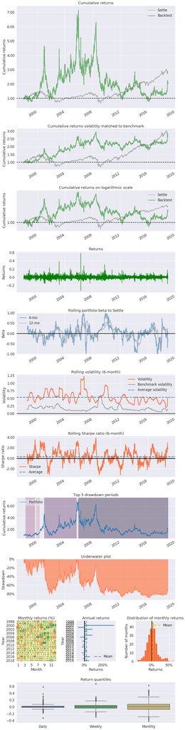

```python
%matplotlib inline

import pyfolio

pyfolio.create_returns_tear_sheet(ng_returns, benchmark_rets=es_returns)
```

plot_ほげほげという関数を使うと個別にグラフを出せます。

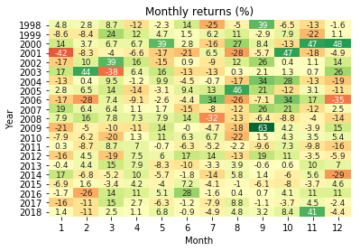

```python
pyfolio.plot_monthly_returns_heatmap(ng_returns)
```

pyfolioはBayesian performance analysisやSector Mappingsなど、さまざまな機能があるのですが疲れ果てたのでここまでとします。

Auther:  
driller  
Books:

[figure not shown]